# **Data-Driven Business Insights: Mengungkap Pola Rental, Geografi Pasar, dan Segmentasi RFM pada Database Sakila**

## 4.3 Visualisasi: Lollipop Chart Actor ROI

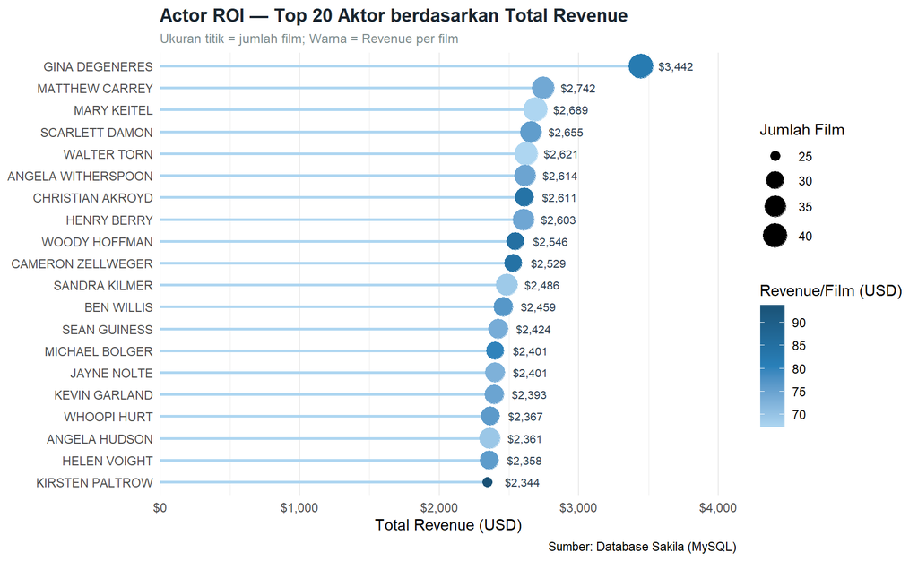

Gambar 1. Total Revenue per Aktor — Top 20 (Lollipop Chart)

```r
df_actor_roi %>%
  mutate(nama_aktor = fct_reorder(nama_aktor, total_revenue)) %>%
  ggplot(aes(x = nama_aktor, y = total_revenue)) +
  geom_segment(aes(xend = nama_aktor, y = 0, yend = total_revenue),
               color = "#aed6f1", size = 1) +
  geom_point(aes(size = jumlah_film, color = revenue_per_film)) +
  geom_text(aes(label = dollar(total_revenue, accuracy = 1, prefix = "$")),
            hjust = -0.5, size = 2.8, color = "#2c3e50") +
  scale_color_gradientn(
    colors = c("#aed6f1","#2980b9","#1a5276"),
    name   = "Revenue/Film (USD)"
  ) +
  scale_size_continuous(name = "Jumlah Film", range = c(3, 8)) +
  scale_y_continuous(labels = dollar_format(),
                     expand = expansion(mult = c(0, 0.2))) +
  coord_flip() +
  labs(
    title    = "Actor ROI — Top 20 Aktor berdasarkan Total Revenue",
    subtitle = "Ukuran titik = jumlah film; Warna = Revenue per film",
    x        = NULL,
    y        = "Total Revenue (USD)",
    caption  = "Sumber: Database Sakila (MySQL)"
  ) +
  theme_minimal(base_size = 11) +
  theme(
    plot.title         = element_text(face = "bold", size = 13, color = "#1a252f"),
    plot.subtitle      = element_text(color = "#7f8c8d", size = 9),
    panel.grid.major.y = element_blank(),
    legend.position    = "right"
  )
```

#### Interpretasi — Actor ROI

Analisis performa finansial berbasis kontribusi aktor pada database Sakila mengonfirmasi bahwa **kuantitas produksi film bukanlah prediktor tunggal keberhasilan finansial**. Ditemukan disparitas yang jelas antara popularitas volume dengan efisiensi pengembalian investasi (ROI), dengan rincian analisis sebagai berikut:

1. **Paradoks Kuantitas vs Efisiensi Finansial:** Data pada tabel menunjukkan bahwa aktor yang memimpin dari sisi absolut total revenue tertinggi (didorong oleh produktivitasnya yang tinggi dalam membintangi banyak judul film) belum tentu memiliki efisiensi pengembalian terbaik. Banyak judul film justru berpotensi meningkatkan biaya pengadaan jika tidak diimbangi dengan rata-rata utilitas penyewaan yang tinggi per proyeknya.
2. **Identifikasi Aset Strategis Utama (High-ROI Drivers):** Sebaliknya, aktor-aktor yang menduduki peringkat atas pada metrik *Revenue per Film* (seperti yang memiliki rata-rata menghasilkan di atas USD 70+ per film) muncul sebagai bintang dengan efisiensi terbaik. Bagi manajemen Sakila, aktor dalam kategori inilah yang menjadi penggerak margin keuntungan (*profit margin drivers*) yang sesungguhnya karena mampu menghasilkan pendapatan maksimal dengan jumlah inventori film yang lebih efisien.
3. **Implikasi Strategis Pengadaan Konten (Content Acquisition):** Hasil evaluasi ini memberikan rekomendasi kuat bagi tim *purchasing* dan pengadaan hak siar film. Kontrak atau lisensi film baru ke depan harus diprioritaskan pada karya-karya yang dibintangi oleh aktor dengan nilai *Revenue per Film* yang tinggi. Strategi ini akan meminimalkan biaya (mengurangi penimbunan judul film yang kurang produktif), namun tetap mampu mengoptimalkan perputaran revenue secara maksimal.